# Введение в МСА. Парная линейная регрессия

### Дата занятия: 10 февраля

## 1. Данные

Напомню, что на занятии мы работали с данными показателя удовлетворенности финансовым положением домохозяйства (*FinSat*) и социального капитала главы семьи (*SocCap*). Данные собраны по 7 домохозяйствам. Первый показатель представлен в шкале от 0 до 10, где 10 –- наиболее высокий уровень удовлетворенности. Социальный капитал измеряется в шкале от 0 до 7, где 7 –- наиболее высокий уровень социального капитала.

Для начала зададим два вектора в R с данными по указанным двум показателям и далее объединим их в один датафрейм. В итоге получили массив данных, в котором 7 строк, каждая из которых соответствует тому или иному домохозяйству, и 2 столбца – 2 показателя *FinSat* и *SocCap*.

```r
FinSat <- c(9,4,8,6,3,2,3)
SocCap <- c(6,1,7,5,0,5,4)
data <- data.frame(FinSat, SocCap)
data
```

| FinSat | SocCap |
| --- | --- |
| 9 | 6 |
| 4 | 1 |
| 8 | 7 |
| 6 | 5 |
| 3 | 0 |
| 2 | 5 |
| 3 | 4 |

Построим диаграмму рассеяния между показателями, FinSat как зависимую переменную расположим по оси OY, а SocCap как объясняющую переменную – по оси OX. С помощью `geom_point()` обозначим на графике точки, соответствующие наблюдениям. Посредством `geom_smooth(method = "lm")` добавим регрессионную прямую, по умолчанию на графике также отображается 95%-ый доверительный интервал для предсказанных моделью значений.

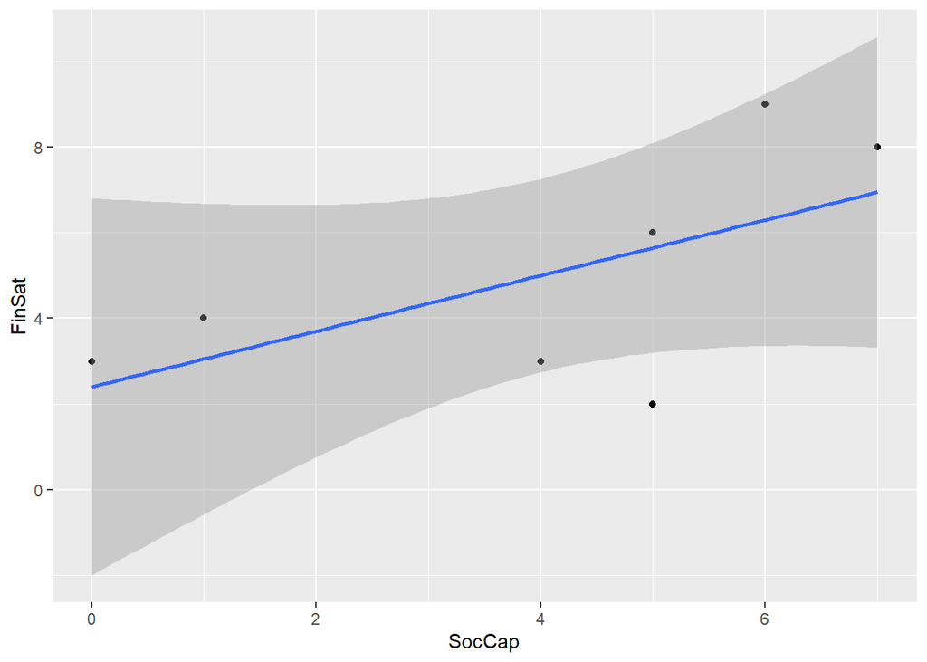

```r
ggplot(data, aes(SocCap, FinSat))+geom_point()+geom_smooth(method = "lm")
```

Регрессионная прямая имеет положительный наклон, что говорит о положительной связи социального капитала и удовлетворенности финансовым положением. Конечно, наблюдений у нас маловато. Неудивительно, что и доверительный интервал получился довольно широким.

## 2. Оценим регрессионную модель

Давайте вспомним, как оценить в R модель линейной регрессии. После того, как мы прописали `lm` в скобках нужно задать саму спецификацию, на первом месте указываем зависимую переменную *FinSat*, после тильды `~` указываем предикторы. В нашем случае – это только одна объясняющая переменная *SocCap*. Выведем результаты, используя `summary(m1)`

```r
m1 <- lm(FinSat ~ SocCap, data)
summary(m1)
```

```
##
## Call:
## lm(formula = FinSat ~ SocCap, data = data)
##
## Residuals:
##     1     2     3     4     5     6     7
##  2.70  0.95  1.05  0.35  0.60 -3.65 -2.00
##
## Coefficients:
##             Estimate Std. Error t value Pr(>|t|)
## (Intercept)   2.4000     1.7153   1.399    0.221
## SocCap        0.6500     0.3681   1.766    0.138
##
## Residual standard error: 2.328 on 5 degrees of freedom
## Multiple R-squared:  0.3841, Adjusted R-squared:  0.2609
## F-statistic: 3.118 on 1 and 5 DF,  p-value: 0.1377
```

### 2.1 Что означают оценки коэффициентов?

В выдаче (см. столбик *Estimate*) видим оценки коэффициентов для константы (*Intercept*) и коэффициента при предикторе (*SocCap*). Оценка константы составляет 2.4, что показывает, что в среднем удовлетворенность финансовым положением составляет 2.4 при условии отсутствия социального капитала. Оценка коэффициента при предикторе равна 0.65, что можно интерпретировать следующим образом: у тех семей, у которых социальный капитал выше на 1, удовлетворенность финансовым положением выше в среднем на 0.65.

### 2.2 Проверка гипотезы о незначимости коэффициента

Также в выдаче представлены стандартные ошибки оценок коэффициентов (*Std. Error*). t-статистики для проверки гипотезы о равенстве коэффициента 0 получаются посредством деления оценки коэффициента на соответствующую стандартную ошибку. К примеру, рассмотрим на примере коэффициента при предикторе, как проверить такую гипотезу.

1. Сформулируем $H_0: b_1 = 0$. Возьмем двустороннюю альтернативу: $H_1: b_1 \neq 0$.
2. Рассчитаем статистику критерия: $\dfrac{\hat{b_1}}{se(\hat{b_1})} = \dfrac{0.65}{0.3681} = 1.766$
3. Мы знаем, что при справедливой нулевой гипотезе статистика критерия имеет распределение Стьюдента с количеством степеней свободы $df=n-k-1$, где $n$ – количество наблюдений, $k$ – количество объясняющих переменных, 1 – не забываем про параметр для константы. Рассчитаем p-value на основе полученного значения статистики. Функцию распределения считаем посредством `pt` (вероятность того, что случайная величина не превысит указанное значение по распредению Стьюдента), задаем df = 5, то есть, 7-2. Значение статистики положительное, поэтому считаем вероятность “хвоста” распределения правее наблюдаемого значения (1.766), то есть, указываем, что `lower.tail = F`. И не забываем домножить на 2, так как речь идет о двусторонней альтернативе.

```r
pt(0.65/0.3681, df = 5, lower.tail = F)*2
```

```
## [1] 0.1376862
```

Получилось в итоге примерно 0.138. Сравним с p-value в таблице с регрессионной выдачей, убедимся, что все верно посчитали. Так как p-value получилось достаточно большое, это говорит о том, что значение статистики ближе к центру распределения – типичным значениям при нулевой гипотезе. Не имеем оснований отвергуть $H_0$, а значит, коэффициент при предикторе неотличим от нуля.

Совершенно необязательно каждый раз переписывать значения коэффициентов и стандартные ошибки из регрессионной таблицы, тем более, в таком случае значения округленные, а значит, не совсем точные. Удобнее вывести вектор оценок параметров следующим образом:

```r
m1$coefficients
```

```
## (Intercept)      SocCap
##        2.40        0.65
```

А затем можно обратиться к необходимому коэффициенту, указав номер параметра. К примеру, если нас интересует оценка коэффициента при предикторе, нужно прописать в квадратных скобках номер параметра [2]. В свою очередь, первый параметр – константа.

```r
m1$coefficients[2]
```

```
## SocCap
##   0.65
```

Возможно также выгрузить ковариационную матрицу оценок коэффициентов и обратиться к ее элементам. К примеру, [2,2] – обращение ко второй строке и второму столбцу – дисперсии $\hat{b_1}$.

```r
vcov(m1)
```

```
##             (Intercept)  SocCap
## (Intercept)    2.942286 -0.5420
## SocCap        -0.542000  0.1355
```

```r
vcov(m1)[2,2]
```

```
## [1] 0.1355
```

Для проверки гипотез о незначимости коэффициентов нужны стандартные ошибки оценок коэффициентов. Для того, чтобы их получить, нужно взять квадратный корень из элементов по главной диагонали ковариационной матрицы. `diag(vcov(m1))` – выведение элементов по главной диагонали.

```r
sqrt(diag(vcov(m1)))
```

```
## (Intercept)      SocCap
##   1.7153092   0.3681032
```

Вернемся к проверке гипотезы о незначимости коэффициента при предикторе *SocCap*. Для того, чтобы сделать функцию более удобной и универсальной, вместо того, чтобы переписывать оценки коэффициентов из таблички, обратимся к нужным элементам из вектора оценок параметров и ковариационной матрицы. Понятно, что значение статистики может быть как положительным, так и отрицательным, поэтому для того, чтобы каждый раз не адаптировать функцию, посчитаем значение статистики по модулю, используя `abs()`. Количество степеней свободы можно также указать автоматически, к примеру, через `df.residual`.

```r
pt(abs(m1$coefficients[2]/sqrt(diag(vcov(m1)))[2]), df = m1$df.residual, lower.tail = F)*2
```

```
##   SocCap
## 0.137689
```

### 2.3 Построение доверительных интервалов для коэффициентов регрессионной модели

Теперь давайте построим 95%-ый доверительный интервал для коэффициента при предикторе *SocCap*. Для начала сделаем это шаг за шагом, последовательно прописывая то, как считается левая и правая границы доверительного интервала. Заодно вспомним логику построения доверительных интервалов. Критическая точка в данном случае – квантиль по распределению Стьюдента (`qt`) уровня 0.975. Еще один способ записать количество степеней свободы – представить как разницу количества наблюдений (первое измерение массива – количество строк – `dim(lab)[1]`) и количества параметров в модели (`length(m1$model)`).

```r
left_boundary <- m1$coefficients[2]-qt(0.975, df = dim(data)[1]-length(m1$model))*sqrt(diag(vcov(m1)))[2]
right_boundary <- m1$coefficients[2]+qt(0.975, df = dim(data)[1]-length(m1$model))*sqrt(diag(vcov(m1)))[2]
c(left_boundary, right_boundary)
```

```
##     SocCap     SocCap
## -0.2962395  1.5962395
```

В R есть и автоматическая функция для построения доверительных интервалов. В первой строке выдачи – границы для доверительного интервала для константы, во второй строке – границы для доверительного интервала для коэффициента при предикторе. Что касается интерпретации, то, к примеру, доверительный интервал для коэффициента при предикторе накрывает 0, следовательно, на 95%-ом уровне доверия можно сказать, что коэффициент при переменной социального капитала неотличим от 0, иными словами, статистически незначим.

```r
confint(m1)
```

```
##                  2.5 %   97.5 %
## (Intercept) -2.0093427 6.809343
## SocCap      -0.2962395 1.596240
```

По умолчанию строится 95%-ый доверительный интервал. Если хотите изменить уровень, пропишите это через `level` следующим образом:

```r
confint(m1, level = 0.99)
```

```
##                  0.5 %   99.5 %
## (Intercept) -4.5163720 9.316372
## SocCap      -0.8342449 2.134245
```

### 2.4 Коэффициент детерминации

В регрессионной выдаче также есть такой показатель, как коэффициент детерминации (R-squared). В данном случае он составляет 0.3841, что говорит о том, что модель позволяет объяснить примерно 38% вариации зависимой переменной. В целом не так-то плохо, с учетом того, что мы оценили парную линейную регрессию.

Если вывести таблицу разложения вариации (для этого воспользуемся `anova()`), то мы увидим, что ESS (explained sum of squares) составляет 16.9, а RSS (residual sum of squares) равна 27.1. Для того, чтобы посчитать R-квадрат, нужно определить долю объясненной вариации, то есть, поделить ESS на TSS (total sum of squares). А TSS, в свою очередь, это сумма ESS и RSS. В нашем случае: $R^2 = \dfrac{16.9}{16.9+27.1} = 0.3841$

```r
anova(m1)
```

|  | Df | Sum Sq | Mean Sq | F value | Pr(>F) |
| --- | --- | --- | --- | --- | --- |
| SocCap | 1 | 16.9 | 16.90 | 3.118081 | 0.137689 |
| Residuals | 5 | 27.1 | 5.42 | NA | NA |